# saltANOVA

Winston Wong

10/26/2020

**Loading Relevant Packages**

Here we load the relevant packages `tidyverse`, `wesanderson`, `rstatix`,`ggpubr`, `fBasics`, `dplyr`, `car` needed to perform the ANOVA, construct graphs, and manipulate data.

```r
library(tidyverse)
library(wesanderson)
library(fBasics)
library(dplyr)
library(car)
library(rstatix)
library(ggpubr)
```

**Loading Relevant Data**

```r
saltANOVAdata = "https://raw.githubusercontent.com/WinstonWong2020/ANOVA-on-A.-thaliana-lines-grown-in-salt-solution/main/SaltANOVA.csv"

saltANOVA <- read_csv(url(saltANOVAdata))
```

**Summary Statistics w/Means**

We first save the saltANOVA.csv as a data frame by using the `as.data.frame()` function and saving it in the object titled `saltANOVA`. After this, the `basicStats()` function from the package `fBasics` is used to create a table containing the relevant summary statistics. The table is saved in the object `summary_statistics_table` using the `as.data.frame()` function.

```r
saltANOVA <- as.data.frame(saltANOVA)

summary_statistics <- basicStats(saltANOVA)[c("Mean", "Stdev", "Variance", "Median", "Minimum", "Maximum"),]

summary_statistics_table <- as.data.frame(summary_statistics)
summary_statistics_table
```

```
##           Control   Line.2   Line.3
## Mean     0.027925 0.037092 0.048958
## Stdev    0.007793 0.007064 0.011611
## Variance 0.000061 0.000050 0.000135
## Median   0.026400 0.035450 0.048450
## Minimum  0.019500 0.024000 0.032100
## Maximum  0.045400 0.052000 0.068900
```

**Checking Distribution of the Data**

The dataset “saltANOVA” is manipulated into a longer format by using the `gather()` function while using `na.rm = T` to omit missing data. The result is saved in the object titled `saltANOVA_longer`.

The dry weights (g) from each group are shown in a boxplot. `ggplot2` in the `tidyverse` package is used to customize and display the boxplot. The mean of the dry weights from each group are marked as a red “X” using `stat_summary(fun="mean" , color="red", shape=4)`. The boxplot is saved in the object titled `dryWeight_boxplot`.

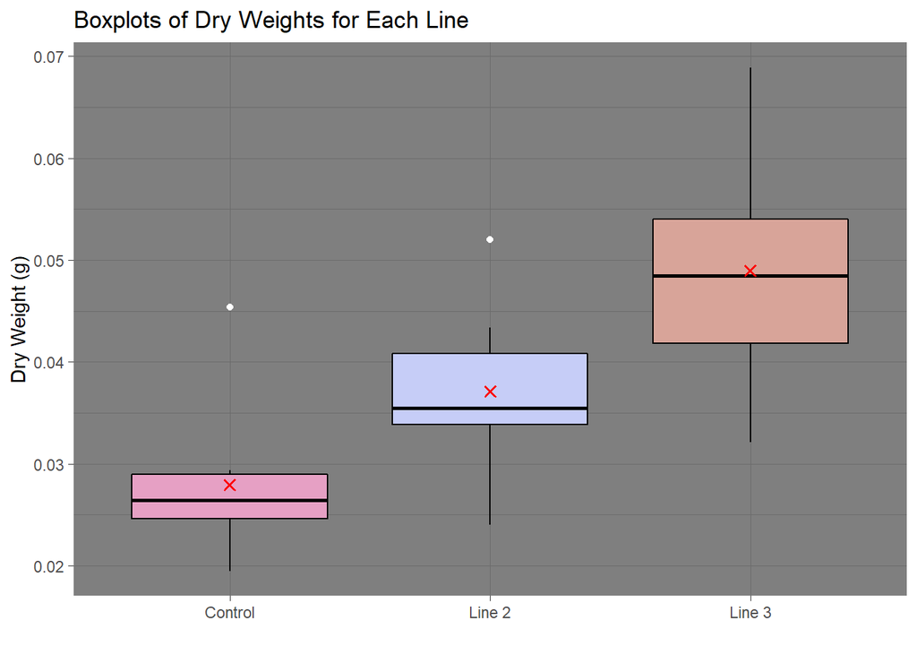

```r
saltANOVA_longer <- gather(saltANOVA, na.rm = T)


#Boxplot of Dry Weights
dryWeight_boxplot <- ggplot(saltANOVA_longer, aes(x=key, y=value, fill = key))+
  geom_boxplot(col="black", outlier.colour = "white")+
  ggtitle("Boxplots of Dry Weights for Each Line")+
  labs(y="Dry Weight (g)", x="") +
  stat_summary(fun="mean", color="red", shape=4)+
  theme_dark()+
  theme(legend.position = "none")+
  scale_fill_manual(values = wes_palette("GrandBudapest2", n = 3))


dryWeight_boxplot
```

From the boxplots, two outliers are identified. We can check if these outliers are extreme by first using the `group_by()` function and then the `identify_outliers()` function from the `rstatix`package. The result is saved as `outlier_output` and then converted into a data frame by using the `as.data.frame()` function. From the table we can see that the outlier in the control group is extreme.

I have chosen to omit this extreme outlier for the ANOVA. The data set with the omitted value is saved as `saltANOVA_longeromit`.

```r
#Checking for Extreme Outliers
outlier_output <- saltANOVA_longer %>% group_by(key) %>% identify_outliers(value)

outlier_table <- as.data.frame(outlier_output)

outlier_table
```

```
##       key  value is.outlier is.extreme
## 1 Control 0.0454       TRUE       TRUE
## 2  Line 2 0.0520       TRUE      FALSE
```

```r
saltANOVA_longeromit <- saltANOVA_longer[-c(2),]
```

**Running a one-way ANOVA on the Data**

The next step is to run the one-way ANOVA.This is done by using the `aov()` function. We will model the difference in the mean of dry weights (g) as a function of line type. From the output we see that our p-value is less than the significance level of 0.05. We reject the null hypothesis and conclude that the mean biomass for all lines is not the same.

```r
#H0: The mean biomass for all lines is the same
#Ha: The mean biomass for all lines is not the same
one.way <- aov(value~key, data = saltANOVA_longeromit)
summary(one.way)
```

```
##             Df   Sum Sq   Mean Sq F value   Pr(>F)
## key          2 0.002523 0.0012615   16.76 1.64e-05 ***
## Residuals   28 0.002108 0.0000753
## ---
## Signif. codes:  0 '***' 0.001 '**' 0.01 '*' 0.05 '.' 0.1 ' ' 1
```

**Conducting Post-Hoc tests**

NOTE: If the extreme outlier in the Control group was not omitted, the difference between Line 2 and Control would not be significant.

```r
TukeyHSD(one.way)
```

```
##   Tukey multiple comparisons of means
##     95% family-wise confidence level
##
## Fit: aov(formula = value ~ key, data = saltANOVA_longeromit)
##
## $key
##                      diff         lwr        upr     p adj
## Line 2-Control 0.01166310 0.001452822 0.02187337 0.0226582
## Line 3-Control 0.02352976 0.013319488 0.03374004 0.0000119
## Line 3-Line 2  0.01186667 0.003102218 0.02063112 0.0063658
```

**Checking for Homogeneity of Variances**

An ANOVA test assumes that the data is normally distributed and that variance across groups are homogeneous. We can test this assumption by using the `leveneTest()` function. Since the p-value is greater than the significance threshold of 0.05, we fail to reject the null hypothesis. We can assume that the variance across groups are homogeneous.

```r
#H0: Population variances are equal
#Ha: Population variances are not equal
leveneTest(value~key, data = saltANOVA_longer)
```

```
## Levene's Test for Homogeneity of Variance (center = median)
##       Df F value Pr(>F)
## group  2  1.2242 0.3087
##       29
```

**Checking Normality**

Another assumption of an ANOVA test is that the residuals are normally distributed. We can test this assumption by first extracting the residuals by using the `residuals()` function and saving the output as `one.way_residuals`. The `shapiro.test()` function is then used to perform an Shapiro-Wilk test on the residuals. Since the p-value is greater than the significance threshold of 0.05, we fail to reject the null hypothesis. We conclude that the residuals are normally distributed.

```r
one.way_residuals <- residuals(object = one.way)

#H0: Residuals are normally distributed.
#Ha: Residuals are not normally distributed.
shapiro.test(x = one.way_residuals)
```

```
##
##  Shapiro-Wilk normality test
##
## data:  one.way_residuals
## W = 0.94987, p-value = 0.1549
```

A normality plot of the residuals can also be used to determine if the residuals are normally distributed. We can create a normality plot by using the `ggqqplot()` function. Most of the points fall on the reference line, indicating the residuals follow an approximately normal distribution.

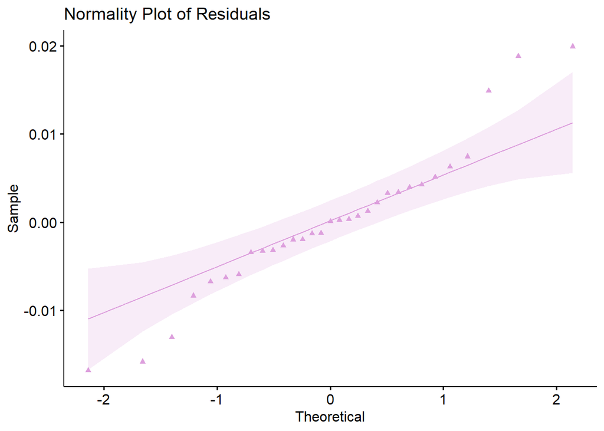

```r
ggqqplot(one.way_residuals, title = "Normality Plot of Residuals", shape = 17, color = "plum")
```